**Statics**

By Prof. Seungchul Lee  
http://iai.postech.ac.kr/  
Industrial AI Lab at POSTECH

Table of Contents

# 1. Statics and Free choice of axis

**Learning goals**

- Solve problems with objects under static equilibrium.
- Learn how to choose the axis location when doing statics problems

**Equilibrium Conditions**

When we say that an object is in static equilibrium, we mean that the object does not rotate or translate. A great fraction of Mechanical and Civil engineering is (very well-developed) statics since many machines and structures have only a few parts designed to move.

**Equilibrium Conditions for a Point Particle**

We can see from Newton's Second Law that a point particle has to experience a zero net force to be in static equilibrium:

> $\sum \vec{F}= 0$

**Equilibrium Conditions for a Rigid Body**

When considering rigid bodies, the body must also experience zero net torque to be in static equilibrium.

In this course, we are only considering rotation in the $x$-$y$ plane, *i.e.* only one axis of rotation, the $z$ axis. We can express the conditions for static equilibrium as simply:

> $\sum \vec{F}= 0$ (for both $x$ and $y$ forces)

If an object is experiencing no rotation or translation, all points are fixed, and we can choose to label the axis of rotation $z$ anywhere on the object. We customarily choose a location that will make calculating torques easier. Often this is a location that will result in zero moment arms for one or more forces, especially ones that are unknown in the problem.

> In statics problems, choose the axis of rotation so as to make the torque calculation as simple as possible.

**Equations of Equilibrium**

$$ \begin{align*} \sum F_x &= 0\\ \sum F_y &= 0\\ \sum M_o &= 0 \end{align*}$$

- Equivalent to solving the system of linear equations

## Moment of a Couple

$$ M = Fd \quad \quad M = r \times F, \quad \text{but }\; F_{net} = 0$$

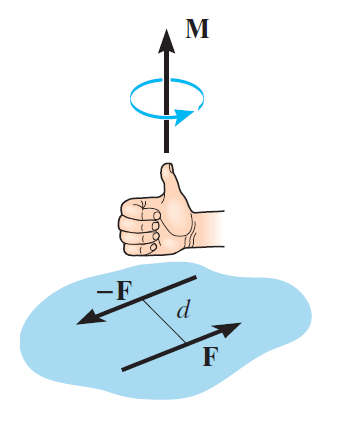

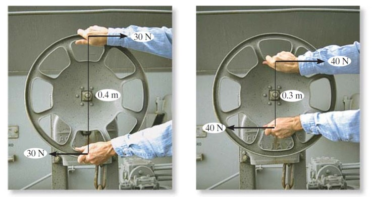

## Free-Body Diagrams

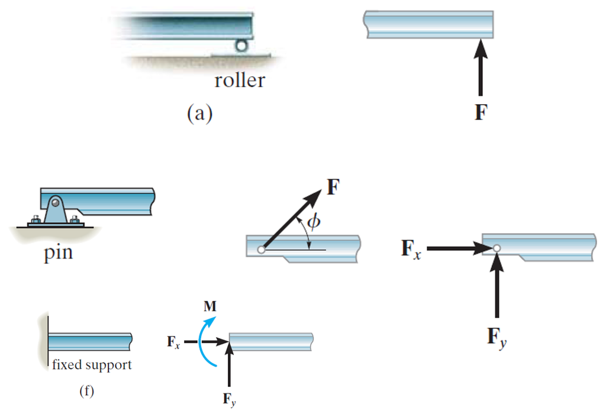

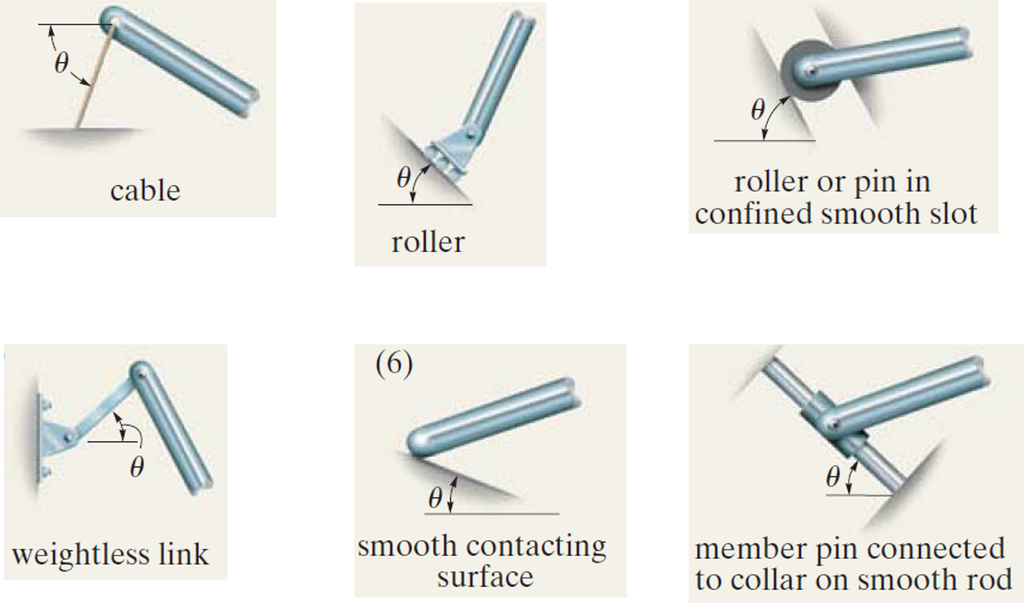

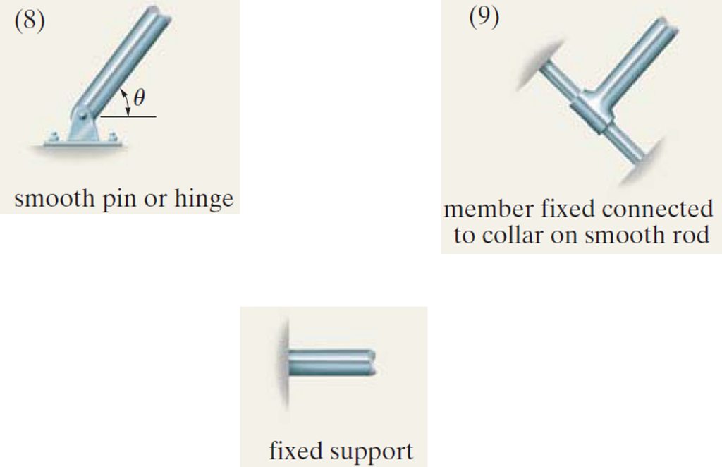

## Exercise

- Determine the moment of the force about point $O$
  - Magnitude
  - Direction
- Static?

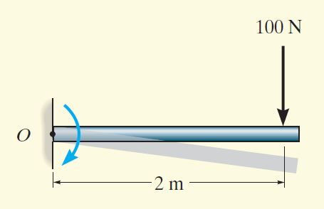

- Describe all the static forces and moments
  - Reaction forces $F_a$ and $F_b$
  - Which one is bigger intuitively?
  - Think about extreme case

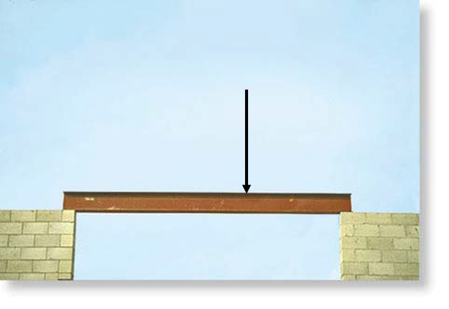

## Exercise

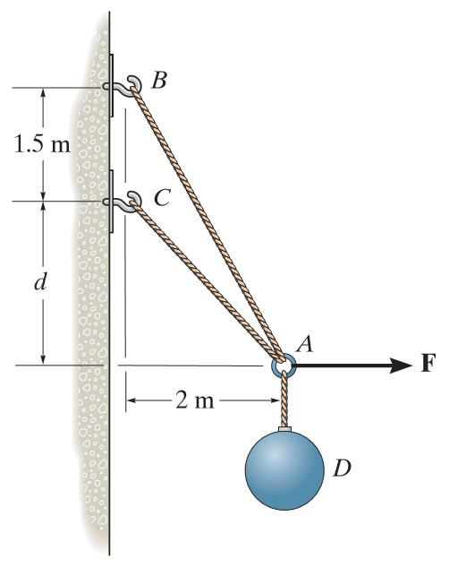

1) Draw free body diagram (FBD)

2) Write down equilibrium equation

3) Determine the dimension $d$ so that the force in cable AC is zero

## Exercise

Draw the free-body diagram of the uniform beam. The beam has a mass of 100 kg.

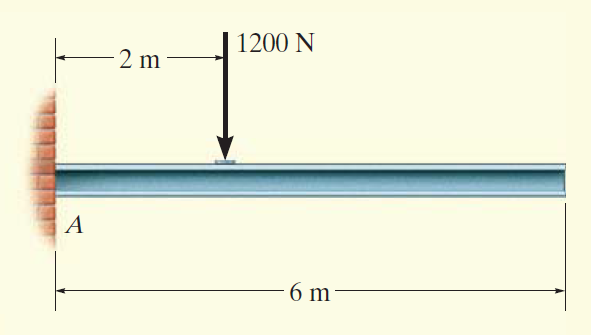

## Exercise

- Determine the horizontal and vertical components of reaction on the member at the pin A, and the normal reaction at the roller B.

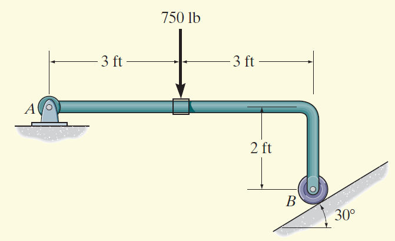

# 2. Structure

## Tension and Compression

- Sign of force vector on bar element
- Sign of force vector on pin ?

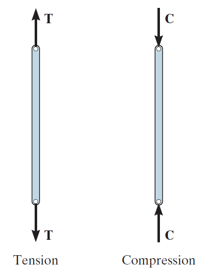

## Method of Joints

- Determine the force in each member of the truss and indicate whether the members are in tension or compression.

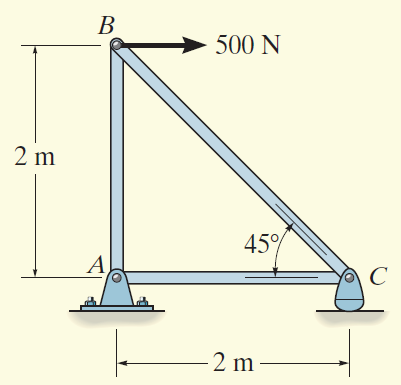